# P5: Identify Fraud from Enron Email

# Background

*Summarize for us the goal of this project and how machine learning is useful in trying to accomplish it. As part of your answer, give some background on the dataset and how it can be used to answer the project question. Were there any outliers in the data when you got it, and how did you handle those? [relevant rubric items: “data exploration”, “outlier investigation”]*

The goal of this project is to use machine learning to identify likely persons of interest (POI) from the Enron corporate fraud. The analysis uses a set of emails sent to and from Enron employees along with financial information related to employee compensation. Machine learning can assist in identifying patterns in email communication and employee compensation that predict POI likely to be involved in the fraud.

The dataset includes records for 146 Enron employees across 22 features. Only 18 of the 146 employees are labeled POI. The ratio of POIs to non-POIs in the dataset makes this project particularly challenging for machine learning. With only 18 POIs out of 146 individuals, the class imbalance means that special attention needs to be paid to classification, particularly during model evaluation and validation.

Several of the features in the dataset have missing values. In particular, the following features have many missing values: deferral_payments, deferred_income, director_fees, loan_advances, and restricted_stock_deferred. Additionally, the dataset includes a “TOTAL” record that is an outlier, likely a quirk of spreadsheet formatting that should be excluded. There are also two other records identified as outliers that were excluded due to missing data and likely not being an actual Enron employee ("LOCKHART EUGENE E" and "THE TRAVEL AGENCY IN THE PARK"). See notes and code below for more detail.

```python
#!/usr/bin/python

import sys
import pickle
import matplotlib.pyplot as plt
import numpy as np
sys.path.append("../tools/")

from feature_format import featureFormat, targetFeatureSplit
from tester import test_classifier, dump_classifier_and_data

r = 42

data_dict = pickle.load(open("final_project_dataset.pkl", "r") )

feature_list = ['poi',
               'bonus',
               'salary',
               'deferral_payments',
               'deferred_income',
               'director_fees',
               'exercised_stock_options',
               'expenses',
               'total_payments',
               'total_stock_value',
               'from_messages',
               'from_poi_to_this_person',
               'from_this_person_to_poi',
               'loan_advances',
               'long_term_incentive',
               'other',
               'restricted_stock',
               'restricted_stock_deferred',
               'salary',
               'shared_receipt_with_poi',
               'to_messages'
               ]

data = featureFormat(data_dict, feature_list)
```

```python
import pandas as pd
pd.set_option('display.max_columns', 30)
pd.set_option('display.width', None)
pd.set_option('display.max_colwidth', 0)

def pandas_df(data_dict):
    df = pd.DataFrame(data_dict)
    df = df.apply(pd.to_numeric, errors='coerce')
    df = df.transpose()
    df.reset_index(level=0, inplace=True)
    c = list(df.columns)
    c[0] = 'name'
    df.columns = c
    return (df)

df = pandas_df(data_dict)
#df.to_csv("dataset.csv")
```

```python
df.head()
```

|  | name | bonus | deferral_payments | deferred_income | director_fees | email_address | exercised_stock_options | expenses | from_messages | from_poi_to_this_person | from_this_person_to_poi | loan_advances | long_term_incentive | other | poi | restricted_stock | restricted_stock_deferred | salary | shared_receipt_with_poi | to_messages | total_payments | total_stock_value |
| --- | --- | --- | --- | --- | --- | --- | --- | --- | --- | --- | --- | --- | --- | --- | --- | --- | --- | --- | --- | --- | --- | --- |
| 0 | ALLEN PHILLIP K | 4175000.00 | 2869717.00 | -3081055.00 | nan | nan | 1729541.00 | 13868.00 | 2195.00 | 47.00 | 65.00 | nan | 304805.00 | 152.00 | 0.00 | 126027.00 | -126027.00 | 201955.00 | 1407.00 | 2902.00 | 4484442.00 | 1729541.00 |
| 1 | BADUM JAMES P | nan | 178980.00 | nan | nan | nan | 257817.00 | 3486.00 | nan | nan | nan | nan | nan | nan | 0.00 | nan | nan | nan | nan | nan | 182466.00 | 257817.00 |
| 2 | BANNANTINE JAMES M | nan | nan | -5104.00 | nan | nan | 4046157.00 | 56301.00 | 29.00 | 39.00 | 0.00 | nan | nan | 864523.00 | 0.00 | 1757552.00 | -560222.00 | 477.00 | 465.00 | 566.00 | 916197.00 | 5243487.00 |
| 3 | BAXTER JOHN C | 1200000.00 | 1295738.00 | -1386055.00 | nan | nan | 6680544.00 | 11200.00 | nan | nan | nan | nan | 1586055.00 | 2660303.00 | 0.00 | 3942714.00 | nan | 267102.00 | nan | nan | 5634343.00 | 10623258.00 |
| 4 | BAY FRANKLIN R | 400000.00 | 260455.00 | -201641.00 | nan | nan | nan | 129142.00 | nan | nan | nan | nan | nan | 69.00 | 0.00 | 145796.00 | -82782.00 | 239671.00 | nan | nan | 827696.00 | 63014.00 |

```python
print "number of features: ", len(df.keys())
print "\n"
group_by_poi = df.groupby(['poi'])
print group_by_poi['poi'].agg([len])
print "\n"

pd.set_option('display.float_format', lambda x: '%.2f' % x)

group_by_poi['bonus',
      'salary',
      'exercised_stock_options',
      'shared_receipt_with_poi',
      'to_messages'].agg(np.median)
```

```
number of features:  22


        len
poi
0.00 128.00
1.00 18.00
```

| poi | bonus | salary | exercised_stock_options | shared_receipt_with_poi | to_messages |
| --- | --- | --- | --- | --- | --- |
| 0.00 | 725000.00 | 254570.00 | 1043324.50 | 594.00 | 944.00 |
| 1.00 | 1275000.00 | 278601.00 | 3914557.00 | 1589.00 | 1875.00 |

```python
d = df.describe()
d = d.transpose()
d
```

|  | count | mean | std | min | 25% | 50% | 75% | max |
| --- | --- | --- | --- | --- | --- | --- | --- | --- |
| bonus | 82.00 | 2374234.61 | 10713327.97 | 70000.00 | 431250.00 | 769375.00 | 1200000.00 | 97343619.00 |
| deferral_payments | 39.00 | 1642674.15 | 5161929.97 | -102500.00 | 81573.00 | 227449.00 | 1002671.50 | 32083396.00 |
| deferred_income | 49.00 | -1140475.14 | 4025406.38 | -27992891.00 | -694862.00 | -159792.00 | -38346.00 | -833.00 |
| director_fees | 17.00 | 166804.88 | 319891.41 | 3285.00 | 98784.00 | 108579.00 | 113784.00 | 1398517.00 |
| email_address | 0.00 | nan | nan | nan | nan | nan | nan | nan |
| exercised_stock_options | 102.00 | 5987053.77 | 31062006.57 | 3285.00 | 527886.25 | 1310813.50 | 2547724.00 | 311764000.00 |
| expenses | 95.00 | 108728.92 | 533534.81 | 148.00 | 22614.00 | 46950.00 | 79952.50 | 5235198.00 |
| from_messages | 86.00 | 608.79 | 1841.03 | 12.00 | 22.75 | 41.00 | 145.50 | 14368.00 |
| from_poi_to_this_person | 86.00 | 64.90 | 86.98 | 0.00 | 10.00 | 35.00 | 72.25 | 528.00 |
| from_this_person_to_poi | 86.00 | 41.23 | 100.07 | 0.00 | 1.00 | 8.00 | 24.75 | 609.00 |
| loan_advances | 4.00 | 41962500.00 | 47083208.70 | 400000.00 | 1600000.00 | 41762500.00 | 82125000.00 | 83925000.00 |
| long_term_incentive | 66.00 | 1470361.45 | 5942759.32 | 69223.00 | 281250.00 | 442035.00 | 938672.00 | 48521928.00 |
| other | 93.00 | 919064.97 | 4589252.91 | 2.00 | 1215.00 | 52382.00 | 362096.00 | 42667589.00 |
| poi | 146.00 | 0.12 | 0.33 | 0.00 | 0.00 | 0.00 | 0.00 | 1.00 |
| restricted_stock | 110.00 | 2321741.14 | 12518278.18 | -2604490.00 | 254018.00 | 451740.00 | 1002369.75 | 130322299.00 |
| restricted_stock_deferred | 18.00 | 166410.56 | 4201494.31 | -7576788.00 | -389621.75 | -146975.00 | -75009.75 | 15456290.00 |
| salary | 95.00 | 562194.29 | 2716369.15 | 477.00 | 211816.00 | 259996.00 | 312117.00 | 26704229.00 |
| shared_receipt_with_poi | 86.00 | 1176.47 | 1178.32 | 2.00 | 249.75 | 740.50 | 1888.25 | 5521.00 |
| to_messages | 86.00 | 2073.86 | 2582.70 | 57.00 | 541.25 | 1211.00 | 2634.75 | 15149.00 |
| total_payments | 125.00 | 5081526.49 | 29061716.40 | 148.00 | 394475.00 | 1101393.00 | 2093263.00 | 309886585.00 |
| total_stock_value | 126.00 | 6773957.45 | 38957772.73 | -44093.00 | 494510.25 | 1102872.50 | 2949846.75 | 434509511.00 |

The counts, above, of values for each feature show that many features have missing values. In particular, the following features have many missing values:

```
- deferral_payments
- deferred_income
- director_fees
- loan_advances
- restricted_stock_deferred
```

Does plotting histograms of each feature highlight any outliers?

```
WARNING: pylab import has clobbered these variables: ['copy']
`%matplotlib` prevents importing * from pylab and numpy
```

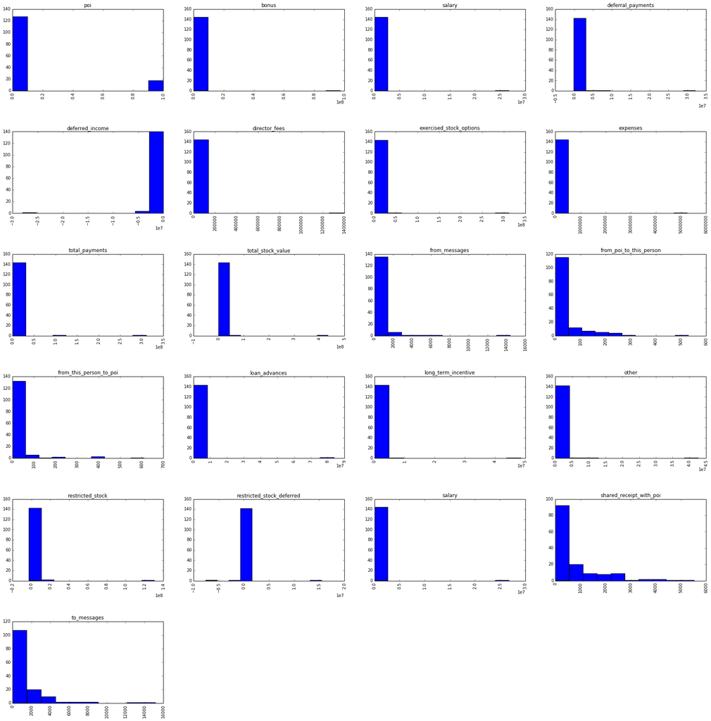

```python
%pylab inline
fig = plt.figure(figsize=(30, 30))

for i, feature in enumerate(feature_list):
    ax = plt.subplot(6,4, i+1)
    plt.title(feature)
    plt.xticks(rotation='vertical')
    plt.subplots_adjust(hspace=.5)
    ax.hist(data[:,i])
```

It's a bit difficult to tell from the histograms, although it seems possible that there are a few outliers given the wide-ranging scale of the x-axis for several of the charts.

Would looking at the top 10 records for a few features help us determine if there are any outliers?

```python
def top_ten_records(feature):
    s = df.sort_values(feature,ascending=False)[['name','poi',feature]]
    print "Top 10 %s records:" % (feature)
    return s[:10]

top_ten_records('bonus')
```

```
Top 10 bonus records:
```

|  | name | poi | bonus |
| --- | --- | --- | --- |
| 130 | TOTAL | 0.00 | 97343619.00 |
| 78 | LAVORATO JOHN J | 0.00 | 8000000.00 |
| 79 | LAY KENNETH L | 1.00 | 7000000.00 |
| 122 | SKILLING JEFFREY K | 1.00 | 5600000.00 |
| 7 | BELDEN TIMOTHY N | 1.00 | 5249999.00 |
| 0 | ALLEN PHILLIP K | 0.00 | 4175000.00 |
| 75 | KITCHEN LOUISE | 0.00 | 3100000.00 |
| 31 | DELAINEY DAVID W | 1.00 | 3000000.00 |
| 139 | WHALLEY LAWRENCE G | 0.00 | 3000000.00 |
| 91 | MCMAHON JEFFREY | 0.00 | 2600000.00 |

```python
top_ten_records('salary')
```

```
Top 10 salary records:
```

|  | name | poi | salary |
| --- | --- | --- | --- |
| 130 | TOTAL | 0.00 | 26704229.00 |
| 122 | SKILLING JEFFREY K | 1.00 | 1111258.00 |
| 79 | LAY KENNETH L | 1.00 | 1072321.00 |
| 47 | FREVERT MARK A | 0.00 | 1060932.00 |
| 105 | PICKERING MARK R | 0.00 | 655037.00 |
| 139 | WHALLEY LAWRENCE G | 0.00 | 510364.00 |
| 32 | DERRICK JR. JAMES V | 0.00 | 492375.00 |
| 43 | FASTOW ANDREW S | 1.00 | 440698.00 |
| 121 | SHERRIFF JOHN R | 0.00 | 428780.00 |
| 112 | RICE KENNETH D | 1.00 | 420636.00 |

Also, do any records have NULL or missing values?

```python
df[(df['bonus'].isnull())
   & (df['deferral_payments'].isnull())
   & (df['deferred_income'].isnull())
   & (df['director_fees'].isnull())
   & (df['email_address'].isnull())
   & (df['exercised_stock_options'].isnull())
   & (df['expenses'].isnull())
   & (df['from_messages'].isnull())
  ]
```

|  | name | bonus | deferral_payments | deferred_income | director_fees | email_address | exercised_stock_options | expenses | from_messages | from_poi_to_this_person | from_this_person_to_poi | loan_advances | long_term_incentive | other | poi | restricted_stock | restricted_stock_deferred | salary | shared_receipt_with_poi | to_messages | total_payments | total_stock_value |
| --- | --- | --- | --- | --- | --- | --- | --- | --- | --- | --- | --- | --- | --- | --- | --- | --- | --- | --- | --- | --- | --- | --- |
| 25 | CLINE KENNETH W | nan | nan | nan | nan | nan | nan | nan | nan | nan | nan | nan | nan | nan | 0.00 | 662086.00 | -472568.00 | nan | nan | nan | nan | 189518.00 |
| 84 | LOCKHART EUGENE E | nan | nan | nan | nan | nan | nan | nan | nan | nan | nan | nan | nan | nan | 0.00 | nan | nan | nan | nan | nan | nan | nan |
| 127 | THE TRAVEL AGENCY IN THE PARK | nan | nan | nan | nan | nan | nan | nan | nan | nan | nan | nan | nan | 362096.00 | 0.00 | nan | nan | nan | nan | nan | 362096.00 | nan |
| 142 | WODRASKA JOHN | nan | nan | nan | nan | nan | nan | nan | nan | nan | nan | nan | nan | 189583.00 | 0.00 | nan | nan | nan | nan | nan | 189583.00 | nan |

Printing the top 10 records shows a record for "TOTAL" included in the dataset. This looks like a quirk of the dataset, not an actual record, so let's reload the dataset with the "TOTAL" line item removed. Looking at records with missing values, it appears that "THE TRAVEL AGENCY IN THE PARK" is not an actual person, and "LOCKHART EUGENE E" has no values associated. Let's also exclude both of these records.

```python
data_dict = pickle.load(open("final_project_dataset.pkl", "r") )

data_dict.pop( "TOTAL", 0 ) # remove "TOTAL" line item
data_dict.pop( "THE TRAVEL AGENCY IN THE PARK", 0 ) # remove "THE TRAVEL AGENCY IN THE PARK" line item
data_dict.pop( "LOCKHART EUGENE E", 0 ) # remove "LOCKHART EUGENE E" line item

feature_list = ['poi',
               'bonus',
               'salary',
               'deferral_payments',
               'deferred_income',
               'director_fees',
               'exercised_stock_options',
               'expenses',
               'total_payments',
               'total_stock_value',
               'from_messages',
               'from_poi_to_this_person',
               'from_this_person_to_poi',
               'loan_advances',
               'long_term_incentive',
               'other',
               'restricted_stock',
               'restricted_stock_deferred',
               'salary',
               'shared_receipt_with_poi',
               'to_messages'
               ]

data = featureFormat(data_dict, feature_list)

df = pandas_df(data_dict)
```

```python
top_ten_records('salary')
```

```
Top 10 salary records:
```

|  | name | poi | salary |
| --- | --- | --- | --- |
| 121 | SKILLING JEFFREY K | 1.00 | 1111258.00 |
| 79 | LAY KENNETH L | 1.00 | 1072321.00 |
| 47 | FREVERT MARK A | 0.00 | 1060932.00 |
| 104 | PICKERING MARK R | 0.00 | 655037.00 |
| 136 | WHALLEY LAWRENCE G | 0.00 | 510364.00 |
| 32 | DERRICK JR. JAMES V | 0.00 | 492375.00 |
| 43 | FASTOW ANDREW S | 1.00 | 440698.00 |
| 120 | SHERRIFF JOHN R | 0.00 | 428780.00 |
| 111 | RICE KENNETH D | 1.00 | 420636.00 |
| 22 | CAUSEY RICHARD A | 1.00 | 415189.00 |

```python
top_ten_records('bonus')
```

```
Top 10 bonus records:
```

|  | name | poi | bonus |
| --- | --- | --- | --- |
| 78 | LAVORATO JOHN J | 0.00 | 8000000.00 |
| 79 | LAY KENNETH L | 1.00 | 7000000.00 |
| 121 | SKILLING JEFFREY K | 1.00 | 5600000.00 |
| 7 | BELDEN TIMOTHY N | 1.00 | 5249999.00 |
| 0 | ALLEN PHILLIP K | 0.00 | 4175000.00 |
| 75 | KITCHEN LOUISE | 0.00 | 3100000.00 |
| 31 | DELAINEY DAVID W | 1.00 | 3000000.00 |
| 136 | WHALLEY LAWRENCE G | 0.00 | 3000000.00 |
| 90 | MCMAHON JEFFREY | 0.00 | 2600000.00 |
| 42 | FALLON JAMES B | 0.00 | 2500000.00 |

```python
top_ten_records('exercised_stock_options')
```

```
Top 10 exercised_stock_options records:
```

|  | name | poi | exercised_stock_options |
| --- | --- | --- | --- |
| 79 | LAY KENNETH L | 1.00 | 34348384.00 |
| 65 | HIRKO JOSEPH | 1.00 | 30766064.00 |
| 111 | RICE KENNETH D | 1.00 | 19794175.00 |
| 121 | SKILLING JEFFREY K | 1.00 | 19250000.00 |
| 102 | PAI LOU L | 0.00 | 15364167.00 |
| 47 | FREVERT MARK A | 0.00 | 10433518.00 |
| 32 | DERRICK JR. JAMES V | 0.00 | 8831913.00 |
| 141 | YEAGER F SCOTT | 1.00 | 8308552.00 |
| 35 | DIMICHELE RICHARD G | 0.00 | 8191755.00 |
| 109 | REDMOND BRIAN L | 0.00 | 7509039.00 |

# Feature Selection and Engineering

*What features did you end up using in your POI identifier, and what selection process did you use to pick them? Did you have to do any scaling? Why or why not? As part of the assignment, you should attempt to engineer your own feature that does not come ready-made in the dataset -- explain what feature you tried to make, and the rationale behind it. (You do not necessarily have to use it in the final analysis, only engineer and test it.) In your feature selection step, if you used an algorithm like a decision tree, please also give the feature importances of the features that you use, and if you used an automated feature selection function like SelectKBest, please report the feature scores and reasons for your choice of parameter values. [relevant rubric items: “create new features”, “properly scale features”, “intelligently select feature”]*

As part of the pipeline for each classifier, different values for k in the automated feature selection function SelectKBest were tested and performance was compared. The top performing classifier, the DecisionTreeClassifier, used the top 19 features identified by SelectKBest (see below for scores). Note that the scores discussed below are only intended to demonstrate the SelectKBest function. The actual feature selection takes place as part of the grid search for tuning the parameters of each classifier.

Included among the top features are two engineered features. The first is, "ratio_to_poi_to_all_sent," and is defined as the number of messages the person sent to a POI divided by the total number of messages sent by that person. The second is, "ratio_from_poi_to_all_received," and is defined as the number of messages received from a POI divided by the total number of messages recieved by that person. The intent of these additional features is to provide additional detail on how the person communicated with POIs, regardless of how often the person uses email. Even if an employee sends only a few emails to a POI, if that is a high proportion of the total emails that person sent, it may be meaningful.

When evaluating classifiers, I used the pipeline and grid search features of scikit-learn to scale features using the MinMaxScaler, select features, and classifier parameters. I generally tried a range of values for each parameter, but did not every parameter due to long run times. I also investigated feature importances from the decision tree classifier.

```python
from sklearn.feature_selection import SelectKBest

def k_best(data_dict, feature_list, k):
    ''' sklearn SelectKBest feature selection, returns dict
    '''
    data = featureFormat(data_dict, feature_list)
    labels, features = targetFeatureSplit(data)

    kn = k + 1
    k_best = SelectKBest(k=(kn))
    k_best.fit(features, labels)
    scores = k_best.scores_

    unsorted_scores = zip(feature_list[1:], scores)
    sorted_scores = sorted(unsorted_scores, key=lambda x: x[1], reverse=True)
    k_best_features = dict(sorted_scores[:kn])
    df_k_best = pd.DataFrame(k_best_features, index=['score'])
    df_k_best = df_k_best.transpose()
    df_k_best = df_k_best.sort_values(['score'],ascending=False)
    print df_k_best
    return k_best_features

k_best(data_dict, feature_list, 10)
```

```
                         score
exercised_stock_options 24.82
total_stock_value       24.18
bonus                   20.79
salary                  18.29
deferred_income         11.46
long_term_incentive     9.92
restricted_stock        9.21
total_payments          8.77
shared_receipt_with_poi 8.59
loan_advances           7.18
```

```
{'bonus': 20.792252047181535,
 'deferred_income': 11.458476579280369,
 'exercised_stock_options': 24.815079733218194,
 'loan_advances': 7.1840556582887247,
 'long_term_incentive': 9.9221860131898225,
 'restricted_stock': 9.2128106219771002,
 'salary': 18.289684043404513,
 'shared_receipt_with_poi': 8.589420731682381,
 'total_payments': 8.7727777300916792,
 'total_stock_value': 24.182898678566879}
```

The table, above, shows the score for each of the top 10 features identified using SelectKBest

```python
import pprint
pp = pprint.PrettyPrinter(depth=6)

import copy
my_dataset = copy.deepcopy(data_dict)
my_feature_list = copy.deepcopy(feature_list)

for k in my_dataset.keys():
    my_dataset[k]['ratio_to_poi_to_all_sent']  = 0
    if (my_dataset[k]['from_poi_to_this_person'] != 'NaN') and (my_dataset[k]['from_messages'] != 'NaN') and (my_dataset[k]['from_messages'] != 0):
        my_dataset[k]['ratio_to_poi_to_all_sent'] = float(my_dataset[k]['from_this_person_to_poi'])/float(my_dataset[k]['from_messages'])

    my_dataset[k]['ratio_from_poi_to_all_received']  = 0
    if (my_dataset[k]['from_this_person_to_poi'] != 'NaN') and (my_dataset[k]['to_messages'] != 'NaN') and (my_dataset[k]['to_messages'] != 0):
        my_dataset[k]['ratio_from_poi_to_all_received'] = float(my_dataset[k]['from_poi_to_this_person'])/float(my_dataset[k]['to_messages'])


for i in ['ratio_to_poi_to_all_sent','ratio_from_poi_to_all_received']:
    if i not in my_feature_list:
        my_feature_list.append(i)

print "Top 10 features from data_dict:"
k_best(data_dict, feature_list, 10)

print('\n' * 2)
print "Top 10 features from my_dataset:"
k_best(my_dataset, my_feature_list, 10)
```

```
Top 10 features from data_dict:
                         score
exercised_stock_options 24.82
total_stock_value       24.18
bonus                   20.79
salary                  18.29
deferred_income         11.46
long_term_incentive     9.92
restricted_stock        9.21
total_payments          8.77
shared_receipt_with_poi 8.59
loan_advances           7.18



Top 10 features from my_dataset:
                          score
exercised_stock_options  24.82
total_stock_value        24.18
bonus                    20.79
salary                   18.29
ratio_to_poi_to_all_sent 16.41
deferred_income          11.46
long_term_incentive      9.92
restricted_stock         9.21
total_payments           8.77
shared_receipt_with_poi  8.59
```

```
{'bonus': 20.792252047181535,
 'deferred_income': 11.458476579280369,
 'exercised_stock_options': 24.815079733218194,
 'long_term_incentive': 9.9221860131898225,
 'ratio_to_poi_to_all_sent': 16.409712548035788,
 'restricted_stock': 9.2128106219771002,
 'salary': 18.289684043404513,
 'shared_receipt_with_poi': 8.589420731682381,
 'total_payments': 8.7727777300916792,
 'total_stock_value': 24.182898678566879}
```

```python
print('\n' * 2)
print "Top 19 features from my_dataset:"
k_best(my_dataset, my_feature_list, 19)
```

```
Top 19 features from my_dataset:
                                score
exercised_stock_options        24.82
total_stock_value              24.18
bonus                          20.79
salary                         18.29
ratio_to_poi_to_all_sent       16.41
deferred_income                11.46
long_term_incentive            9.92
restricted_stock               9.21
total_payments                 8.77
shared_receipt_with_poi        8.59
loan_advances                  7.18
expenses                       6.09
from_poi_to_this_person        5.24
other                          4.19
ratio_from_poi_to_all_received 3.13
from_this_person_to_poi        2.38
director_fees                  2.13
to_messages                    1.65
deferral_payments              0.22
```

```
{'bonus': 20.792252047181535,
 'deferral_payments': 0.22461127473600989,
 'deferred_income': 11.458476579280369,
 'director_fees': 2.1263278020077054,
 'exercised_stock_options': 24.815079733218194,
 'expenses': 6.0941733106389453,
 'from_poi_to_this_person': 5.2434497133749582,
 'from_this_person_to_poi': 2.3826121082276739,
 'loan_advances': 7.1840556582887247,
 'long_term_incentive': 9.9221860131898225,
 'other': 4.1874775069953749,
 'ratio_from_poi_to_all_received': 3.1280917481567263,
 'ratio_to_poi_to_all_sent': 16.409712548035788,
 'restricted_stock': 9.2128106219771002,
 'salary': 18.289684043404513,
 'shared_receipt_with_poi': 8.589420731682381,
 'to_messages': 1.6463411294420076,
 'total_payments': 8.7727777300916792,
 'total_stock_value': 24.182898678566879}
```

# Try Different Algorithms

*What algorithm did you end up using? What other one(s) did you try? How did model performance differ between algorithms? [relevant rubric item: “pick an algorithm”]*

I ended up using the Decision Tree classifier, due to best performance, Precision: 0.38272 Recall: 0.38100

*What does it mean to tune the parameters of an algorithm, and what can happen if you don’t do this well? How did you tune the parameters of your particular algorithm? (Some algorithms do not have parameters that you need to tune -- if this is the case for the one you picked, identify and briefly explain how you would have done it for the model that was not your final choice or a different model that does utilize parameter tuning, e.g. a decision tree classifier). [relevant rubric item: “tune the algorithm”]*

Tuning the parameters means adjusting the parameter arguments for the dataset and use case. If you don't do this well, the classifier can have poor performance during cross validation and fail to predict any unseen data. Cross-validation is used to tune the parameters of the classifiers. If we tuned parameters only using training data, the model would overfit. I used the grid search feature in scikit-learn to comprehensively compare a variety of parameter settings.

For example, for the Decision Tree classifier that ended up with the best performance, I varied the following attributes to see which yielded the highest F1 score:

- max_features: None, 'auto', 'log2'
- criterion: 'gini', 'entropy'
- min_samples_split: 2, 3, 4, 5, 10

*What is validation, and what’s a classic mistake you can make if you do it wrong? How did you validate your analysis? [relevant rubric item: “validation strategy”]*

Validation involves randomly splitting the dataset into separate training and testing groups. The model is trained on the training dataset, and then performance is evaluated on the test dataset. This process helps validate the performance on an independent dataset and guards against overfitting. For this analysis, due to the low number of POI, I used the statified shuffle split function in conjunction with grid search in scikit-learn for cross validation over 1000 folds. I also used the test_classifier method from the tester script provided, which also performs stratified cross-valudation evaluation.

*Give at least 2 evaluation metrics and your average performance for each of them. Explain an interpretation of your metrics that says something human-understandable about your algorithm’s performance. [relevant rubric item: “usage of evaluation metrics”]*

### Gaussian Naive Bayes

```python
## Gaussian Naive Bayes

from sklearn.grid_search import GridSearchCV
from sklearn.naive_bayes import GaussianNB
from sklearn.feature_selection import SelectKBest, f_classif
from sklearn.preprocessing import MinMaxScaler
from sklearn.pipeline import Pipeline, FeatureUnion


from sklearn.cross_validation import StratifiedShuffleSplit
my_data = featureFormat(my_dataset, my_feature_list, sort_keys = True)
labels, feature_values = targetFeatureSplit(my_data)
folds = 1000
cv = StratifiedShuffleSplit(
     labels, folds, random_state=r)

clf = GaussianNB()
steps = [
    ('scale', MinMaxScaler()),
    ('select_features',SelectKBest(f_classif)),
    ('my_classifier', clf)
    ]

parameters = dict(select_features__k=[3,5,9,15,19,21,'all'])

pipe = Pipeline(steps)

grid = GridSearchCV(pipe, param_grid=parameters, cv=cv, verbose=1, scoring='f1', n_jobs=4)

grid.fit(feature_values, labels)

print("The best parameters are %s with a score of %0.4f"
      % (grid.best_params_, grid.best_score_))

# The best parameters are {'select_features__k': 'all'} with a score of 0.3248
# Pipeline(steps=[('scale', MinMaxScaler(copy=True, feature_range=(0, 1))), ('select_features', SelectKBest(k='all', score_func=<function f_classif at 0x115589e60>)), ('my_classifier', GaussianNB())])
# 	Accuracy: 0.53120	Precision: 0.19280	Recall: 0.78950	F1: 0.30991	F2: 0.48765
# 	Total predictions: 15000	True positives: 1579	False positives: 6611	False negatives:  421	True negatives: 6389


gnb_classifier = grid.best_estimator_

# use test_classifier to evaluate
test_classifier(gnb_classifier, my_dataset, my_feature_list)
```

```
Fitting 1000 folds for each of 7 candidates, totalling 7000 fits
```

```
The best parameters are {'select_features__k': 'all'} with a score of 0.3248
Pipeline(steps=[('scale', MinMaxScaler(copy=True, feature_range=(0, 1))), ('select_features', SelectKBest(k='all', score_func=<function f_classif at 0x115589e60>)), ('my_classifier', GaussianNB())])
	Accuracy: 0.53120	Precision: 0.19280	Recall: 0.78950	F1: 0.30991	F2: 0.48765
	Total predictions: 15000	True positives: 1579	False positives: 6611	False negatives:  421	True negatives: 6389
```

The naive bayes classifier yeilds Recall score as 0.78950 and Precision score of 0.19280, below the target of at least 0.3.

### K Nearest Neighbors

```python
## KNeighborsClassifier

from sklearn.grid_search import GridSearchCV
from sklearn.neighbors import KNeighborsClassifier
from sklearn.feature_selection import SelectKBest, f_classif
from sklearn.preprocessing import MinMaxScaler
from sklearn.pipeline import Pipeline, FeatureUnion


from sklearn.cross_validation import StratifiedShuffleSplit
my_data = featureFormat(my_dataset, my_feature_list, sort_keys = True)
labels, feature_values = targetFeatureSplit(my_data)
folds = 1000
cv = StratifiedShuffleSplit(
     labels, folds, random_state=r)

clf = KNeighborsClassifier()
steps = [
    ('scale', MinMaxScaler()),
    ('select_features',SelectKBest(f_classif)),
    ('my_classifier', clf)
    ]

parameters = dict(select_features__k=[1,2,3,4,5,6,7,9,11,13,15,17,19,21],
              my_classifier__n_neighbors=[1,2,3,4,5,6,7,8,9,13,15,20])

pipe = Pipeline(steps)

grid = GridSearchCV(pipe, param_grid=parameters, cv=cv, verbose=1, scoring='f1', n_jobs=4)

grid.fit(feature_values, labels)

print("The best parameters are %s with a score of %0.2f"
      % (grid.best_params_, grid.best_score_))

# The best parameters are {'my_classifier__n_neighbors': 1, 'select_features__k': 6} with a score of 0.30


knn_classifier = grid.best_estimator_

# evaluate with test_classifier function
test_classifier(knn_classifier, my_dataset, my_feature_list)

# Pipeline(steps=[('scale', MinMaxScaler(copy=True, feature_range=(0, 1))), ('select_features', SelectKBest(k=6, score_func=<function f_classif at 0x115f53de8>)), ('my_classifier', KNeighborsClassifier(algorithm='auto', leaf_size=30, metric='minkowski',
#            metric_params=None, n_jobs=1, n_neighbors=1, p=2,
#            weights='uniform'))])
# 	Accuracy: 0.80733	Precision: 0.30187	Recall: 0.33900	F1: 0.31936	F2: 0.33086
# 	Total predictions: 15000	True positives:  678	False positives: 1568	False negatives: 1322	True negatives: 11432
```

```
Fitting 1000 folds for each of 168 candidates, totalling 168000 fits
```

```
The best parameters are {'my_classifier__n_neighbors': 1, 'select_features__k': 3} with a score of 0.27
Pipeline(steps=[('scale', MinMaxScaler(copy=True, feature_range=(0, 1))), ('select_features', SelectKBest(k=3, score_func=<function f_classif at 0x115589e60>)), ('my_classifier', KNeighborsClassifier(algorithm='auto', leaf_size=30, metric='minkowski',
           metric_params=None, n_jobs=1, n_neighbors=1, p=2,
           weights='uniform'))])
	Accuracy: 0.81427	Precision: 0.29805	Recall: 0.29000	F1: 0.29397	F2: 0.29157
	Total predictions: 15000	True positives:  580	False positives: 1366	False negatives: 1420	True negatives: 11634
```

### Decision Tree

```python
## DecisionTreeClassifier

from sklearn.grid_search import GridSearchCV
from sklearn.tree import DecisionTreeClassifier

from sklearn.feature_selection import SelectKBest, f_classif
from sklearn.preprocessing import MinMaxScaler
from sklearn.pipeline import Pipeline, FeatureUnion


from sklearn.cross_validation import StratifiedShuffleSplit
my_data = featureFormat(my_dataset, my_feature_list, sort_keys = True)
labels, feature_values = targetFeatureSplit(my_data)
folds = 1000
cv = StratifiedShuffleSplit(
     labels, folds, random_state=r)

clf = DecisionTreeClassifier(random_state=r)
steps = [
    ('scale', MinMaxScaler()),
    ('select_features',SelectKBest(f_classif)),
    ('my_classifier', clf)
    ]

parameters = dict(select_features__k=[1,2,3,4,5,6,7,8,9,10,11,12,13,14,15,16,17,18,19,20,21,'all'],
                  my_classifier__max_features=[None, 'auto', 'log2'],
                  my_classifier__criterion=['gini', 'entropy'],
                  my_classifier__min_samples_split=[2, 3, 4, 5, 10]
                 )

pipe = Pipeline(steps)

grid = GridSearchCV(pipe, param_grid=parameters, cv=cv, verbose=1, scoring='f1', n_jobs=4)

grid.fit(feature_values, labels)

print("The best parameters are %s with a score of %0.4f"
      % (grid.best_params_, grid.best_score_))

# The best parameters are {'my_classifier__min_samples_split': 2, 'select_features__k': 17, 'my_classifier__criterion': 'gini', 'my_classifier__max_features': 'auto'} with a score of 0.3857

dt_classifier = grid.best_estimator_

test_classifier(dt_classifier, my_dataset, my_feature_list)


# Pipeline(steps=[('scale', MinMaxScaler(copy=True, feature_range=(0, 1))), ('select_features', SelectKBest(k=17, score_func=<function f_classif at 0x1140e0050>)), ('my_classifier', DecisionTreeClassifier(class_weight=None, criterion='gini', max_depth=None,
#             max_features='auto', max_leaf_nodes=None, min_samples_leaf=1,
#             min_samples_split=2, min_weight_fraction_leaf=0.0,
#             presort=False, random_state=42, splitter='best'))])
# 	Accuracy: 0.84233	Precision: 0.40934	Recall: 0.41200	F1: 0.41067	F2: 0.41147
# 	Total predictions: 15000	True positives:  824	False positives: 1189	False negatives: 1176	True negatives: 11811
```

```
Fitting 1000 folds for each of 660 candidates, totalling 660000 fits
```

[output not shown]

```
The best parameters are {'my_classifier__min_samples_split': 3, 'select_features__k': 19, 'my_classifier__criterion': 'entropy', 'my_classifier__max_features': None} with a score of 0.3590
Pipeline(steps=[('scale', MinMaxScaler(copy=True, feature_range=(0, 1))), ('select_features', SelectKBest(k=19, score_func=<function f_classif at 0x121232050>)), ('my_classifier', DecisionTreeClassifier(class_weight=None, criterion='entropy', max_depth=None,
            max_features=None, max_leaf_nodes=None, min_samples_leaf=1,
            min_samples_split=3, min_weight_fraction_leaf=0.0,
            presort=False, random_state=42, splitter='best'))])
	Accuracy: 0.83553	Precision: 0.38272	Recall: 0.38100	F1: 0.38186	F2: 0.38134
	Total predictions: 15000	True positives:  762	False positives: 1229	False negatives: 1238	True negatives: 11771
```

Next, look at the importance metrics from the decision tree.

```python
dt_importances = dt_classifier.steps[-1][1].feature_importances_
sorted_indices = np.argsort(dt_importances)[::-1] # [::-1] shortcut to reverse the list

for i in range(10):
    print("{0:d}. {1} ({2:.2f})".format(i + 1, feature_list[1:][sorted_indices[i]], dt_importances[sorted_indices[i]]))
```

```
1. long_term_incentive (0.23)
2. to_messages (0.20)
3. expenses (0.18)
4. from_poi_to_this_person (0.10)
5. exercised_stock_options (0.09)
6. restricted_stock_deferred (0.06)
7. deferred_income (0.05)
8. total_payments (0.03)
9. from_messages (0.02)
10. other (0.02)
```

### RandomForestClassifier

```python
## RandomForestClassifier

from sklearn.grid_search import GridSearchCV
from sklearn.ensemble import RandomForestClassifier

from sklearn.feature_selection import SelectKBest, f_classif
from sklearn.preprocessing import MinMaxScaler
from sklearn.pipeline import Pipeline, FeatureUnion


from sklearn.cross_validation import StratifiedShuffleSplit
my_data = featureFormat(my_dataset, my_feature_list, sort_keys = True)
labels, feature_values = targetFeatureSplit(my_data)
folds = 1000
cv = StratifiedShuffleSplit(
     labels, folds, random_state=r)

clf = RandomForestClassifier(random_state=r)
steps = [
    ('scale', MinMaxScaler()),
    ('select_features',SelectKBest(f_classif)),
    ('my_classifier', clf)
    ]

parameters = dict(select_features__k=[3,5,9,15,19,21,'all'],
                  my_classifier__max_features=[None, 'auto', 'log2'],
                  my_classifier__criterion=['gini', 'entropy'],
                  my_classifier__min_samples_split=[2, 3, 4, 5, 10]
                 )

pipe = Pipeline(steps)

grid = GridSearchCV(pipe, param_grid=parameters, cv=cv, verbose=1, scoring='f1', n_jobs=4)

grid.fit(feature_values, labels)

print("The best parameters are %s with a score of %0.4f"
      % (grid.best_params_, grid.best_score_))


# The best parameters are {'my_classifier__min_samples_split': 10,
#                          'select_features__k': 3,
#                          'my_classifier__criterion': 'entropy',
#                          'my_classifier__max_features': None} with a score of 0.2985


rf_classifier = grid.best_estimator_

test_classifier(rf_classifier, my_dataset, my_feature_list)
```

```
Fitting 1000 folds for each of 210 candidates, totalling 210000 fits
```

[output not shown]

```
The best parameters are {'my_classifier__min_samples_split': 5, 'select_features__k': 3, 'my_classifier__criterion': 'gini', 'my_classifier__max_features': None} with a score of 0.2620
Pipeline(steps=[('scale', MinMaxScaler(copy=True, feature_range=(0, 1))), ('select_features', SelectKBest(k=3, score_func=<function f_classif at 0x115589e60>)), ('my_classifier', RandomForestClassifier(bootstrap=True, class_weight=None, criterion='gini',
            max_depth=None, max_features=None, max_lea...stimators=10, n_jobs=1,
            oob_score=False, random_state=42, verbose=0, warm_start=False))])
	Accuracy: 0.84187	Precision: 0.36733	Recall: 0.25750	F1: 0.30276	F2: 0.27388
	Total predictions: 15000	True positives:  515	False positives:  887	False negatives: 1485	True negatives: 12113
```